# Survey Deoccupied Hromadas

Valentyn Hatsko

Last updated: 2023-02-15

> This report visualizes key information about Resilience Survey

*Important Definitions*

> Research Sample: Hromadas who responded to the survey.

# Environment

> Reviews the components of the working environment of the report. Non-technical readers are welcomed to skip. Come back if you need to understand the origins of custom functions, scripts, or data objects.

**Packages used**

Packages used in current report

**External scripts**

Collection of custom functions used in current repository (`sda-information-requests`)

**Global values**

Values used throughout the report.

**Functions**

Custom functions defined for use in this report.

# Data

## Input

**click to glimpse**

```r
ds_survey %>% glimpse()
```

```
Rows: 138
Columns: 260
$ index                                              <dbl> 12, 82, 85, 93, 102, 23, 61, 133, 140, ~
$ today                                              <dttm> 2022-10-19, 2022-11-01, 2022-11-01, 20~
$ `_id`                                              <dbl> 194017568, 196954519, 196999969, 197222~
$ hromada_code                                       <chr> "UA05100110000070795", "UA0510017000007~
$ hromada_name                                       <chr> "Студенянська", "Шпиківська", "Калинівс~
$ hromada_full_name                                  <chr> "Студенянська сільська громада", "Шпикі~
$ raion_code                                         <chr> "UA05100000000022396", "UA0510000000002~
$ raion_name                                         <chr> "Тульчинський", "Тульчинський", "Хмільн~
$ oblast_code                                        <chr> "UA05000000000010236", "UA0500000000001~
$ oblast_name                                        <chr> "Вінницька", "Вінницька", "Вінницька", ~
$ region_en                                          <chr> "Center", "Center", "Center", "Center",~
$ region_en.y                                        <chr> "Center", "Center", "Center", "Center",~
$ deoccupied_at_feb_2023                             <dbl> 0, 0, 0, 0, 0, 0, 0, 0, 0, 0, 0, 0, 0, ~
```

[output cut: 247 more lines]

```r
meta_survey %>% filter(group == 'preamble')
```

```
# A tibble: 1 x 14
  group    item_~1 label~2 label~3 type  name  label requi~4 appea~5 media~6 relev~7 const~8 const~9
  <chr>      <dbl> <chr>   <chr>   <chr> <chr> <chr> <list>  <chr>   <chr>   <chr>   <chr>   <chr>
1 preamble      NA <NA>    <NA>    note  <NA>  "Суп~ <NULL>  <NA>    kse_in~ <NA>    <NA>    <NA>
# ... with 1 more variable: hint <chr>, and abbreviated variable names 1: item_number, 2: label_en,
#   3: label_ua, 4: required, 5: appearance, 6: `media::image`, 7: relevant, 8: constraint,
#   9: constraint_message
```

```r
ds_survey %>% pull(hromada_code) %>% unique()
```

```
  [1] "UA05100110000070795" "UA05100170000071290" "UA05120070000075759" "UA05060130000030729"
  [5] "UA05020110000052014" "UA07060370000022360" "UA07080170000013585" "UA07020130000036300"
  [9] "UA07060290000054842" "UA07060390000098670" "UA12060190000043514" "UA12040170000019083"
 [13] "UA12100030000084605" "UA12140150000054570" "UA12040210000039759" "UA12100050000045992"
 [17] "UA12040030000066040" "UA12080070000077032" "UA12140110000060935" "UA12140250000015858"
 [21] "UA12140270000072109" "UA12020130000022909" "UA18020050000058053" "UA18060170000069581"
 [25] "UA18040410000025491" "UA21120190000082169" "UA21020070000015036" "UA21080190000094580"
 [29] "UA21080150000014443" "UA21040250000010914" "UA21100130000055002" "UA21080070000025254"
 [33] "UA21060070000049340" "UA21020130000047547" "UA21040110000099623" "UA21120130000025618"
 [37] "UA23060230000071243" "UA23060130000058533" "UA23060150000085288" "UA26060250000064599"
 [41] "UA26060090000054411" "UA26040230000035526" "UA26040130000010870" "UA26060170000091466"
 [45] "UA26120050000087602" "UA26040110000023512" "UA26100050000019570" "UA26060110000025739"
 [49] "UA26040290000025886" "UA26040270000047749" "UA26060030000011364" "UA26060130000047466"
 [53] "UA26120070000067596" "UA26040350000024417" "UA26080070000092582" "UA32120090000034281"
 [57] "UA32140070000012102" "UA32080210000074136" "UA32020230000012716" "UA32060030000048241"
```

[output cut: 20 more lines]

Next, we define useful sets of variable names to be used throughout the report

**click to see the groups**

```
 [1] "help_for_military"             "evacuation_actions"            "idp_help"
 [4] "special_fund_relocation_needs" "bussiness_stimules"            "hromada_cooperation"
 [7] "hromada_problem_inv_labels"    "hromada_problem_info"          "hromada_problem_consultation"
[10] "hromada_problem_proposition"   "hromada_problem_system"        "hromada_problem_feedback"
[13] "hromada_problem_execution"     "skills_needed"
```

```
 [1] "prep_first_aid_water"            "prep_first_aid_fuel"
 [3] "prep_reaction_plan"              "prep_evacuation_plan"
 [5] "prep_reaction_plan_oth_hromadas" "prep_reaction_plan_oda"
 [7] "prep_dftg_creation"              "prep_national_resistance"
 [9] "prep_starosta_meeting"           "prep_communal_meetiing"
[11] "prep_online_map"                 "prep_shelter_list"
[13] "prep_notification_check"         "prep_backup"
[15] "prep_partly_backup"
```

```
[1] "telegram"  "viber"     "facebook"  "chat_help" "hotline"
```

```
[1] "idp_help/communal_placement" "idp_help/private_placement"  "idp_help/regular_meal"
[4] "idp_help/humanitar_help"     "idp_help/fundraising"        "idp_help/employ"
[7] "idp_help/psych_help"         "idp_help/law_help"           "idp_help/transit_center"
```

```
[1] "help_for_military/rooms"     "help_for_military/transport" "help_for_military/money"
[4] "help_for_military/products"  "help_for_military/other"     "help_for_military/none"
```

```
[1] "hromada_cooperation/medicine"   "hromada_cooperation/food"
[3] "hromada_cooperation/pensions"   "hromada_cooperation/evacuation"
[5] "hromada_cooperation/other"      "hromada_cooperation/none"
```

```
[1] "skills_needed/fundraising"        "skills_needed/project_management"
[3] "skills_needed/longterm_planning"  "skills_needed/crisis_planning"
[5] "skills_needed/data_analysis"      "skills_needed/human_resourse"
[7] "skills_needed/other"
```

```
[1] "own_income_prop_2021"   "transfert_prop_2021"    "military_tax_prop_2021"
[4] "pdfo_prop_2021"         "unified_tax_prop_2021"  "property_tax_prop_2021"
[7] "excise_duty_prop_2021"
```

**meta data**

```r
meta_survey %>% glimpse()
```

```
Rows: 132
Columns: 14
$ group              <chr> NA, NA, NA, NA, NA, NA, "preamble", "general_information", "general_inf~
$ item_number        <dbl> NA, NA, NA, NA, NA, NA, NA, NA, NA, NA, NA, NA, NA, NA, NA, NA, NA, NA,~
$ label_en           <chr> NA, NA, NA, NA, NA, NA, NA, NA, NA, NA, NA, NA, NA, NA, NA, NA, NA, NA,~
$ label_ua           <chr> NA, NA, NA, NA, NA, NA, NA, NA, NA, NA, NA, NA, NA, NA, NA, NA, NA, NA,~
$ type               <chr> "start", "end", "today", "deviceid", "begin_group", "begin_group", "not~
$ name               <chr> "start", "end", "today", "deviceid", "general_information", "general_in~
$ label              <chr> NA, NA, NA, NA, NA, NA, "Супротив України у загарбницькій війні Російсь~
$ required           <list> <NULL>, <NULL>, <NULL>, <NULL>, <NULL>, "field-list", <NULL>, TRUE, TR~
$ appearance         <chr> NA, NA, NA, NA, NA, NA, NA, NA, NA, NA, NA, NA, NA, NA, NA, NA, NA, NA,~
$ `media::image`     <chr> NA, NA, NA, NA, NA, NA, "kse_institute.png", NA, NA, NA, NA, NA, NA, NA~
$ relevant           <chr> NA, NA, NA, NA, NA, NA, NA, NA, NA, NA, NA, NA, NA, NA, NA, NA, NA, NA,~
$ constraint         <chr> NA, NA, NA, NA, NA, NA, NA, NA, NA, NA, NA, NA, NA, NA, NA, NA, NA, NA,~
$ constraint_message <chr> NA, NA, NA, NA, NA, NA, NA, NA, NA, NA, NA, NA, NA, NA, NA, NA, NA, NA,~
$ hint               <chr> NA, NA, NA, NA, NA, NA, "Заповнення опитувальника займе орієнтовно 25 х~
```

```r
meta_survey %>%
  filter(type %in% c("begin_group","end_group")) %>%
  select(1:5) %>%
  print_all()
```

```
# A tibble: 32 x 5
   group item_number label_en label_ua type
   <chr>       <dbl> <chr>    <chr>    <chr>
 1 <NA>           NA <NA>     <NA>     begin_group
 2 <NA>           NA <NA>     <NA>     begin_group
 3 <NA>           NA <NA>     <NA>     end_group
 4 <NA>           NA <NA>     <NA>     end_group
 5 <NA>           NA <NA>     <NA>     begin_group
 6 <NA>           NA <NA>     <NA>     end_group
 7 <NA>           NA <NA>     <NA>     begin_group
 8 <NA>           NA <NA>     <NA>     end_group
 9 <NA>           NA <NA>     <NA>     begin_group
10 <NA>           NA <NA>     <NA>     begin_group
11 <NA>           NA <NA>     <NA>     end_group
12 <NA>           NA <NA>     <NA>     end_group
```

[output cut: 20 more lines]

```r
meta_survey %>% glimpse()
```

```
Rows: 132
Columns: 14
$ group              <chr> NA, NA, NA, NA, NA, NA, "preamble", "general_information", "general_inf~
$ item_number        <dbl> NA, NA, NA, NA, NA, NA, NA, NA, NA, NA, NA, NA, NA, NA, NA, NA, NA, NA,~
$ label_en           <chr> NA, NA, NA, NA, NA, NA, NA, NA, NA, NA, NA, NA, NA, NA, NA, NA, NA, NA,~
$ label_ua           <chr> NA, NA, NA, NA, NA, NA, NA, NA, NA, NA, NA, NA, NA, NA, NA, NA, NA, NA,~
$ type               <chr> "start", "end", "today", "deviceid", "begin_group", "begin_group", "not~
$ name               <chr> "start", "end", "today", "deviceid", "general_information", "general_in~
$ label              <chr> NA, NA, NA, NA, NA, NA, "Супротив України у загарбницькій війні Російсь~
$ required           <list> <NULL>, <NULL>, <NULL>, <NULL>, <NULL>, "field-list", <NULL>, TRUE, TR~
$ appearance         <chr> NA, NA, NA, NA, NA, NA, NA, NA, NA, NA, NA, NA, NA, NA, NA, NA, NA, NA,~
$ `media::image`     <chr> NA, NA, NA, NA, NA, NA, "kse_institute.png", NA, NA, NA, NA, NA, NA, NA~
$ relevant           <chr> NA, NA, NA, NA, NA, NA, NA, NA, NA, NA, NA, NA, NA, NA, NA, NA, NA, NA,~
$ constraint         <chr> NA, NA, NA, NA, NA, NA, NA, NA, NA, NA, NA, NA, NA, NA, NA, NA, NA, NA,~
$ constraint_message <chr> NA, NA, NA, NA, NA, NA, NA, NA, NA, NA, NA, NA, NA, NA, NA, NA, NA, NA,~
$ hint               <chr> NA, NA, NA, NA, NA, NA, "Заповнення опитувальника займе орієнтовно 25 х~
```

## Transformations

For the state `ds0`, we augment the focal table of the report with additional columns and transform existing variable to better fit visualization/modeling needs

```r
ds_general0 <-
  ds_general %>%
  mutate(
    survey_response = case_when(
      hromada_code %in% (ds_survey %>% pull(hromada_code) %>% unique()) ~ TRUE
      ,TRUE ~ FALSE
    )
  )
# ds_general0 %>% group_by(survey_response) %>% count()

ds_general1 <- ds_general %>%
  mutate(oblast_name_en = case_when(oblast_name_en == 'Vonyn' ~ "Volyn",
                                    oblast_name_en == 'Driproptrovska' ~ "Dnipropetrovska",
                                    TRUE ~ oblast_name_en)
  )

ds0 <-
  ds_survey %>%
  mutate(
    income_own_per_capita       = income_own_2021         / total_population_2022,
    income_total_per_capita     = income_total_2021       / total_population_2022,
    income_tranfert_per_capita  = income_transfert_2021   / total_population_2022,
    idp_registration_share      = idp_registration_number / total_population_2022,
    idp_real_share              = idp_real_number         / total_population_2022 * 100,
    idp_child_share             = idp_child_education     / idp_registration_number * 100,
    type                        = case_when(type == 'сільська' ~ 'village',
                                            type == 'селищна' ~ 'urban village',
                                            type == 'міська' ~ 'urban'),
    type = factor(type, levels  = c("village", "urban village", "urban")),
    help_military_count         = rowSums(across(all_of(military_help_short))),
    idp_help_count              = rowSums(across(all_of(idp_help))),
    occupation_and_combat       = case_when(military_action == 'no_combat' & occupation == 'not_occupied' ~ 0,
                                            TRUE ~ 1),
    occupation_and_combat_fct   = factor(occupation_and_combat,
                                         labels = c('Rear communities',
                                                    'Communities exposed to war (n = 22)')),
    occupation_fct              = factor(deoccupied_at_feb_2023,
                                         labels = c('Rear communities',
                                                    'Deoccupied communities (n = 16)')),
    voluntary_fct               = factor(voluntary,
                                         labels = c('Top-down amalgamated', 'Voluntary amalgamated')),
    oblast_name_en              = case_when(oblast_name_en == 'Vonyn' ~ "Volyn",
                                            oblast_name_en == 'Driproptrovska' ~ "Dnipropetrovska",
                                            TRUE ~ oblast_name_en)
     )

ds1_winter_prep <- ds0 %>%
  mutate(
    winter_prep_count = rowSums(across(info_campaign:solid_fuel_boiler), na.rm = T)
    ,winter_prep_count = case_when(
      occupation =='not_occupied' | occupation == 'occupied_april' ~ winter_prep_count
      ,TRUE ~ NA_real_
    )
  )

ds1_problem <- ds0 %>%
  mutate(
    hromada_exp = ifelse(hromada_exp == "yes", 1, 0)
    ,problem_info_index         =           ifelse(`hromada_problem_info/nobody`==1, 0,
                                           rowSums(across(contains("hromada_problem_info/"))))
    ,problem_consultation_index =   ifelse(`hromada_problem_consultation/nobody`==1, 0,
                                           rowSums(across(contains("hromada_problem_consultation/"))))
    ,problem_proposition_index  =   ifelse(`hromada_problem_proposition/nobody`==1, 0,
                                           rowSums(across(contains("hromada_problem_proposition/"))))
    ,problem_system_index       =   ifelse(`hromada_problem_system/nobody`==1, 0,
                                           rowSums(across(contains("hromada_problem_system/"))))
    ,problem_feedback_index     =   ifelse(`hromada_problem_feedback/nobody`==1, 0,
                                           rowSums(across(contains("hromada_problem_feedback/"))))
    ,problem_execution_index    =   ifelse(`hromada_problem_execution/nobody`==1, 0,
                                           rowSums(across(contains("hromada_problem_execution/"))))
    ,problem_additive_index     =   .4*problem_info_index + .6*problem_consultation_index +
      .6*problem_proposition_index + .8*problem_system_index + .8*problem_feedback_index +
      problem_execution_index
  )
```

To make our analysis more nimble we create four alternative versions of `ds1` with Invasion Preparedness questions

**show transformations**

```r
# compute total binary score (preparations are made at all, regardless of timing)
d_meta_prep <-
  meta_survey %>%
  filter(group=="preparation") %>%
  select(item_name = name,label_en,label)

ds1_prep <-
  ds0 %>%
  mutate(
    # sum of 0|1|2 where larger numbers indicate more preparedness
    prep_score_combo = rowSums(across(all_of(preparation)),na.rm = T)
    ,prep_score_feb = rowSums(
      across(
        .cols = preparation
        ,.fns = ~case_when(
          .  == 0 ~ 0 #"No"
          ,. == 1 ~ 0 #"After Feb 24"
          ,. == 2 ~ 1 #"Before Feb 24"
        )
      )
      ,na.rm = T
    )
    ,prep_score_oct = rowSums(
      across(
        .cols = preparation
        ,.fns = ~case_when(
          .  == 0 ~ 0 #"No"
          ,. == 1 ~ 1 #"After Feb 24"
          ,. == 2 ~ 1 #"Before Feb 24"
        )
      )
      ,na.rm = T
    )
  )  %>%
  select(hromada_code, starts_with("prep_score"),preparation)
ds1_prep %>% select(1:4)
```

```
# A tibble: 138 x 4
   hromada_code        prep_score_combo prep_score_feb prep_score_oct
   <chr>                          <dbl>          <dbl>          <dbl>
 1 UA05100110000070795               12              0             12
 2 UA05100170000071290                9              0              9
 3 UA05120070000075759               18              5             13
 4 UA05060130000030729               13              2             11
 5 UA05020110000052014               14              3             11
 6 UA07060370000022360               17              3             14
 7 UA07080170000013585               19              4             15
 8 UA07020130000036300               12              1             11
 9 UA07060290000054842               17              2             15
10 UA07060390000098670                7              0              7
# ... with 128 more rows
```

```r
## Some handy datasets for quick visualization
# Raw scale (0,1,2) with factors
ds1_prep_ordinal_factors <-
  ds1_prep %>%
  mutate(
    across(
      .cols = preparation
      ,.fns = ~case_when(
        . == 0  ~ "No"
        ,. == 1 ~ "As of Oct"
        ,. == 2 ~ "As of Feb"
        ,TRUE   ~ "Not Applicable"
      ) %>% factor(levels=c("No","As of Oct","As of Feb",  "Not Applicable"))
    )
  ) %>%
  select(hromada_code, starts_with("prep_score"),preparation)

# Binary scale (0,1) with factors
ds1_prep_binary_factors <-
  ds1_prep %>%
  mutate(
    across(
      .cols = preparation
      ,.fns = ~case_when(
        .  == 0  ~ "No"
        ,. == 1 ~ "Yes"
        ,. == 2 ~ "Yes"
        ,TRUE   ~ "Not Applicable"
      ) %>% factor(levels=c("No","Yes","Not Applicable"))
    )
  ) %>%
  select(hromada_code, starts_with("prep_score"),preparation)

# Binary scale (0,1) with factors
ds1_prep_binary_factors_feb <-
  ds1_prep %>%
  mutate(
    across(
      .cols = preparation
      ,.fns = ~case_when(
        .  == 0  ~ "No"
        ,. == 1 ~ "No"
        ,. == 2 ~ "Yes"
        ,TRUE   ~ "No"
      ) %>% factor(levels=c("No","Yes"))
    )
  ) %>%
  select(hromada_code, starts_with("prep_score"),preparation)
```

```r
d_meta_info <-
  meta_survey %>%
  filter(group== "information") %>%
  select(item_name = name,label_en,item_number)
meta_choices %>% filter(list_name=="commun_prep")
```

```
# A tibble: 3 x 4
  list_name   name      label                         label_en
  <chr>       <chr>     <chr>                         <chr>
1 commun_prep before_24 Було створено до 24 лютого    <NA>
2 commun_prep after_24  Було створено після 24 лютого <NA>
3 commun_prep none      Немає                         <NA>
```

```r
item_information <- d_meta_info %>% pull(item_name)

ds1_info <-
  ds0 %>%
  mutate(
    across(
      .cols = item_information
      ,.fns = ~case_when(
        . == 0  ~ "No"
        ,. == 1 ~ "After Feb 24"
        ,. == 2 ~ "Before Feb 24"
        ,TRUE   ~ "Not Applicable"
      ) %>% factor(levels=c("No","Before Feb 24","After Feb 24",  "Not Applicable"))
    )
  ) %>%
  select(hromada_code,item_information)
```

**examine the versions**

# Variable List

The following variables are present in the processed data table of survey responses:

```r
ds0 %>% explore::describe_all() %>%neat_DT()
```

|  | variable | type | na | na_pct | unique | min | mean | max |
| --- | --- | --- | --- | --- | --- | --- | --- | --- |
| 1 | index | dbl | 0 | 0 | 138 | 2 | 78.2 | 151 |
| 2 | today | dat | 0 | 0 | 30 |  |  |  |
| 3 | _id | dbl | 0 | 0 | 138 | 191541757 | 197322877.2 | 206471695 |
| 4 | hromada_code | chr | 0 | 0 | 138 |  |  |  |
| 5 | hromada_name | chr | 0 | 0 | 135 |  |  |  |
| 6 | hromada_full_name | chr | 0 | 0 | 137 |  |  |  |
| 7 | raion_code | chr | 0 | 0 | 76 |  |  |  |
| 8 | raion_name | chr | 0 | 0 | 76 |  |  |  |
| 9 | oblast_code | chr | 0 | 0 | 22 |  |  |  |
| 10 | oblast_name | chr | 0 | 0 | 22 |  |  |  |

[output cut: 261 more lines]

# 0. Introduction

0.1 What is the goal of this report?

> This report overviews the responses to the survey conducted by KSE Institute in Ukraine during 2022

# 1. General Information

```r
meta_survey %>% filter(group=="preamble") %>% pull(label) %>% cat()
```

```
Супротив України у загарбницькій війні Російської Федерації великою мірою пов’язаний зі стійкістю, яку виявили територіальні громади.
Щоб оцінити, як різні потрясіння вплинули на громади та перевірити, які фактори впливають на стійкість громад у війні, Київська Школа Економіки проводить опитування.
Ми гарантуємо конфіденційність Ваших відповідей. Всі отримані дані будуть аналізуватись тільки в узагальненому вигляді.
Крайній термін заповнення анкети - 4 листопада.
```

1.1 How many hromadas contributed responses to so far?

> As of 2023-02-15, 138 hromadas contributed valid response to the survey

1.2 What regions are represented in this sample?

```r
ds_survey %>%
  group_by(region_en) %>%
  summarize(
    hromada_count = n_distinct(hromada_code)
    ,.groups = "drop"
  ) %>%
  mutate(hromada_survey_prop = hromada_count / sum(hromada_count)
         ,hromada_survey_pct = scales::percent(hromada_survey_prop, accuracy = .1)) %>%
  right_join(
    ds_general %>%
      group_by(region_en) %>%
      summarize(hromada_count_total = n())
  ) %>%
  filter(!is.na(region_en)) %>%
  mutate(
    hromada_count = replace_na(hromada_count, 0)
    ,hromada_total_prop = hromada_count_total / sum(hromada_count_total)
    ,hromada_total_pct = scales::percent(hromada_total_prop, accuracy = .1)
  ) %>%
  arrange(region_en, desc(hromada_survey_prop)) %>%
  select(-c(hromada_survey_prop, hromada_total_prop)) %>%
  relocate(hromada_count_total, .after = hromada_count) %>%
  ungroup() %>%
  # neat_DT()
  gt::gt() %>%
  gt::cols_label(region_en = 'Region',
                 hromada_count_total = 'Total number \nof ATCs',
                 hromada_count = 'ATCs in the survey',
                 hromada_total_pct = 'Proportion of Region \nin the General Population',
                 hromada_survey_pct = 'Proportion of Region \nin the Survey'
  )
```

| Region | ATCs in the survey | Total number of ATCs | Proportion of Region in the Survey | Proportion of Region in the General Population |
| --- | --- | --- | --- | --- |
| Center | 24 | 298 | 17.4% | 20.7% |
| East | 19 | 281 | 13.8% | 19.5% |
| North | 23 | 243 | 16.7% | 16.9% |
| South | 20 | 192 | 14.5% | 13.4% |
| West | 52 | 424 | 37.7% | 29.5% |

1.3 What oblasts are represented in this sample?

```r
ds0 %>%
  summarize(
    hromada_count = n_distinct(hromada_code)
    ,deoccupied_count = sum(deoccupied_at_feb_2023)
    ,.by = c(region_en, oblast_name_en)
  ) %>%
  mutate(hromada_survey_prop = hromada_count / sum(hromada_count)
         ,hromada_survey_pct = scales::percent(hromada_survey_prop, accuracy = .1)) %>%
  right_join(
    ds_general1 %>%
      group_by(region_en, oblast_name_en) %>%
      summarize(hromada_count_total = n())
  ) %>%
  filter(!is.na(region_en)) %>%
  mutate(
    hromada_count = replace_na(hromada_count, 0)
    ,hromada_total_prop = hromada_count_total / sum(hromada_count_total)
    ,hromada_total_pct = scales::percent(hromada_total_prop, accuracy = .1)
  ) %>%
  arrange(region_en, desc(hromada_survey_prop)) %>%
  select(-c(hromada_survey_prop, hromada_total_prop)) %>%
  relocate(hromada_count_total, .after = hromada_count) %>%
  ungroup() %>%
  mutate(oblast_name_en = case_when(oblast_name_en == "Vonyn" ~ "Volyn",
                                    oblast_name_en == "Driproptrovska" ~ "Dnipro",
                                    TRUE ~ oblast_name_en)) %>%
  # neat_DT()
  gt::gt() %>%
  gt::cols_label(region_en = 'Region',
                 oblast_name_en = 'Oblast',
                 hromada_count_total = 'Total number \nof ATCs',
                 hromada_count = 'ATCs in the survey',
                 deoccupied_count = "Deoccupied at Feb 2023 ATCs",
                 hromada_total_pct = 'Proportion of Oblast \nin the General Population',
                 hromada_survey_pct = 'Proportion of Oblast \nin the Survey'
  ) %>%
  tab_row_group(
    label = "Center"
    ,rows = region_en == "Center"
  ) %>%
  tab_row_group(
    label = "East"
    ,rows = region_en == "East"
  ) %>%
    tab_row_group(
    label = "North"
    ,rows = region_en == "North"
  ) %>%
    tab_row_group(
    label = "South"
    ,rows = region_en == "South"
  ) %>%
    tab_row_group(
    label = "West"
    ,rows = region_en == "West"
    ) %>%
  cols_hide(region_en)
```

| Oblast | ATCs in the survey | Total number of ATCs | Deoccupied at Feb 2023 ATCs | Proportion of Oblast in the Survey | Proportion of Oblast in the General Population |
| --- | --- | --- | --- | --- | --- |
| West |  |  |  |  |  |
| Ivano-Frankivsk | 16 | 62 | 0 | 11.6% | 4.3% |
| Zakarpatska | 11 | 64 | 0 | 8.0% | 4.5% |
| Lviv | 9 | 73 | 0 | 6.5% | 5.1% |
| Volyn | 5 | 54 | 0 | 3.6% | 3.8% |
| Rivenska | 4 | 64 | 0 | 2.9% | 4.5% |
| Ternopilska | 4 | 55 | 0 | 2.9% | 3.8% |
| Cherniveska | 3 | 52 | 0 | 2.2% | 3.6% |
| South |  |  |  |  |  |
| Odesa | 12 | 91 | 0 | 8.7% | 6.3% |
| Kherson | 7 | 49 | 4 | 5.1% | 3.4% |
| Mykolayiv | 1 | 52 | 0 | 0.7% | 3.6% |
| North |  |  |  |  |  |
| Sumska | 8 | 51 | 6 | 5.8% | 3.5% |
| Chernigiv | 7 | 57 | 5 | 5.1% | 4.0% |
| Kyiv-oblast | 5 | 69 | 1 | 3.6% | 4.8% |
| Zhytomir | 3 | 66 | 0 | 2.2% | 4.6% |
| East |  |  |  |  |  |
| Dnipropetrovska | 12 | 86 | 0 | 8.7% | 6.0% |
| Kharkiv | 4 | 56 | 0 | 2.9% | 3.9% |
| Zaporizka | 3 | 67 | 0 | 2.2% | 4.7% |
| Donetks | 0 | 46 | NA | NA | 3.2% |
| Luhansk | 0 | 26 | NA | NA | 1.8% |
| Center |  |  |  |  |  |
| Poltava | 8 | 60 | 0 | 5.8% | 4.2% |
| Vinnytsia | 5 | 63 | 0 | 3.6% | 4.4% |
| Kirovograd | 5 | 49 | 0 | 3.6% | 3.4% |
| Cherkassy | 5 | 66 | 0 | 3.6% | 4.6% |
| Khmelnitsk | 1 | 60 | 0 | 0.7% | 4.2% |

1.4 What type of hromadas are represented in the sample?

```r
ds0 %>%
  group_by(type) %>%
  summarize(
    hromada_count = n_distinct(hromada_code)
    ,.groups = "drop"
  ) %>%
  mutate(hromada_survey_prop = hromada_count / sum(hromada_count)
         ,hromada_survey_pct = scales::percent(hromada_survey_prop, accuracy = .1)) %>%
  right_join(
    ds_general %>%
      group_by(type) %>%
      summarize(hromada_count_total = n())
  ) %>%
  mutate(
    hromada_count = replace_na(hromada_count, 0)
    ,hromada_total_prop = hromada_count_total / sum(hromada_count_total)
    ,hromada_total_pct = scales::percent(hromada_total_prop, accuracy = .1)
    ,type = case_when(type == 'міська' ~ "urban",
                      type == 'селищна' ~ "urban village",
                      type == 'сільська' ~ "village"
                      )
  ) %>%
  arrange(factor(type, levels = c('urban', "urban village", "village"))) %>%
  select(-c(hromada_survey_prop, hromada_total_prop)) %>%
  relocate(hromada_count_total, .after = hromada_count) %>%
  ungroup() %>%
  # neat_DT()
  gt::gt() %>%
  gt::cols_label(type = 'Type of Hromada',
                 hromada_count_total = 'Total number \nof ATCs',
                 hromada_count = 'ATCs in the survey',
                 hromada_total_pct = 'Proportion of Hromada Type \nin the General Population',
                 hromada_survey_pct = 'Proportion of Hromada Type \nin the Survey'
  )
```

| Type of Hromada | ATCs in the survey | Total number of ATCs | Proportion of Hromada Type in the Survey | Proportion of Hromada Type in the General Population |
| --- | --- | --- | --- | --- |
| urban | 0 | 409 | NA | 27.8% |
| urban village | 0 | 435 | NA | 29.6% |
| village | 0 | 625 | NA | 42.5% |

1.5 What hromadas experienced military occupation or military actions?

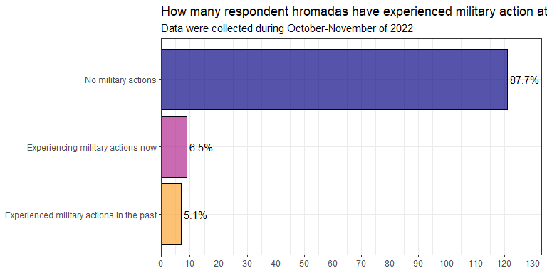

```r
(ds0 %>% make_bi_freq_graph("military_action")) +
  labs(
    title = "How many respondent hromadas have experienced military action at the time of the interview?"
    ,subtitle = "Data were collected during October-November of 2022"
    ,x = NULL
    ,y = NULL
    ,fill = NULL
  ) +
  scale_x_discrete(labels=c('no_combat' = 'No military actions', 'combat_now' = 'Experiencing military actions now', "combat_ended" = "Experienced military actions in the past")) +
  guides(fill = "none") +
  theme_bw()
```

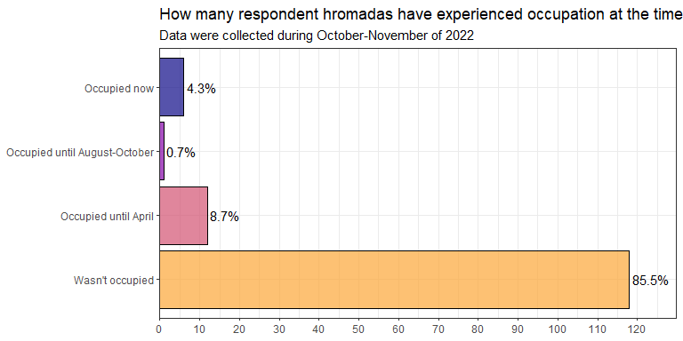

Crosstable of Hromadas that experienced occupation and/or military actions

|  | Wasn't occupied | Occupied until April | Occupied until August-October | Occupied now |
| --- | --- | --- | --- | --- |
| Experienced military actions in the past | 1 | 6 | 0 | 0 |
| Experiencing military actions now | 1 | 3 | 1 | 4 |
| No military actions | 116 | 3 | 0 | 2 |

```r
(ds0 %>% make_bi_freq_graph("occupation"))+
  labs(
    title = "How many respondent hromadas have experienced occupation at the time of the interview?"
    ,subtitle = "Data were collected during October-November of 2022"
    ,y=NULL
    ,x=NULL
  ) +
  scale_x_discrete(labels=c('occupied_now' = 'Occupied now', 'occupied_august' = 'Occupied until August-October', "occupied_april" = "Occupied until April", "not_occupied" = "Wasn't occupied")) +
  guides(fill = "none") +
  theme_bw()
```

1.6 How many partherships with other hromadas in Ukraine hromadas have?

> Median number of partnerships that hromada has is 0, mean - 1.34. Maximum number of partnerships that hromada has in our survey is 20.

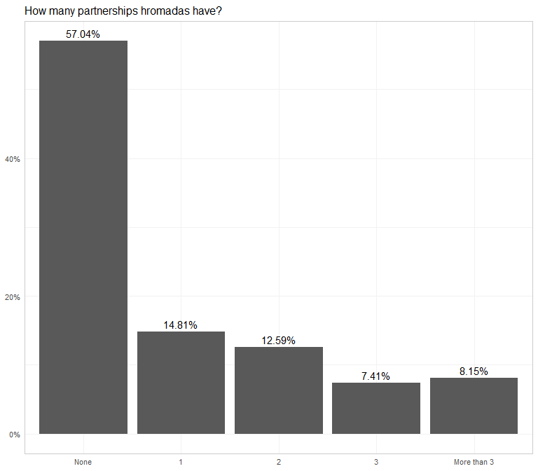

> These are hromadas in our survey that have the most partnerships:

| Hromada Name | Number of hromada's partnerships in Ukraine |
| --- | --- |
| Ясінянська селищна громада | 20 |
| Кутська селищна громада | 20 |
| Коломийська міська громада | 10 |
| Бориславська міська громада | 7 |
| Брошнів-Осадська селищна громада | 6 |

1.6 How many hromadas-friends abroad hromadas have?

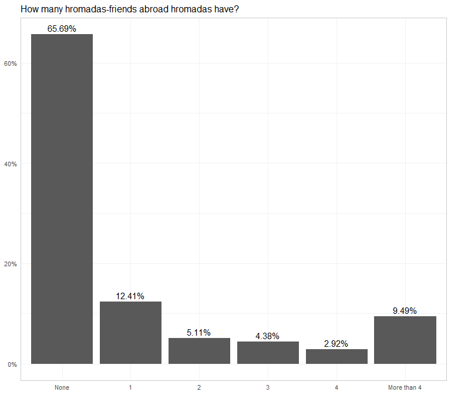

```r
ds0 %>%
  mutate(friends_text = as.numeric(friends_text)) %>%
  select(hromada_full_name, friends_text) %>%
  mutate(friends_group = cut(friends_text,
                              breaks = c(0, 1, 2, 3, 4, 5, 20),
                              labels = c('None', '1', '2', '3', '4', 'More than 4'),
                              right = F)) %>%
  na.omit() %>%
  ggplot(aes(x=friends_group, group = 1)) +
  geom_bar(aes(y = ..prop..), stat = 'count') +
  geom_text(aes(label = scales::percent(..prop..), y = ..prop..), stat = 'count', vjust = -.4) +
  scale_y_continuous(labels = scales::percent_format()) +
  labs(
    title = "How many hromadas-friends abroad hromadas have?"
    ,y = NULL, x = NULL
  )
```

> These are hromadas in our survey that have the most friends abroad:

| Hromada Name | Number of hromada's friends abroad |
| --- | --- |
| Луцька міська громада | 17 |
| Тячівська міська громада | 13 |
| Перечинська міська громада | 12 |
| Коломийська міська громада | 11 |
| Самбірська міська громада | 11 |
| Нововолинська міська громада | 10 |
| Великобийганська сільська громада | 9 |
| Долинська міська громада | 7 |
| Миргородська міська громада | 7 |
| Бориславська міська громада | 6 |
| Болградська міська громада | 6 |

# 2. Preparation

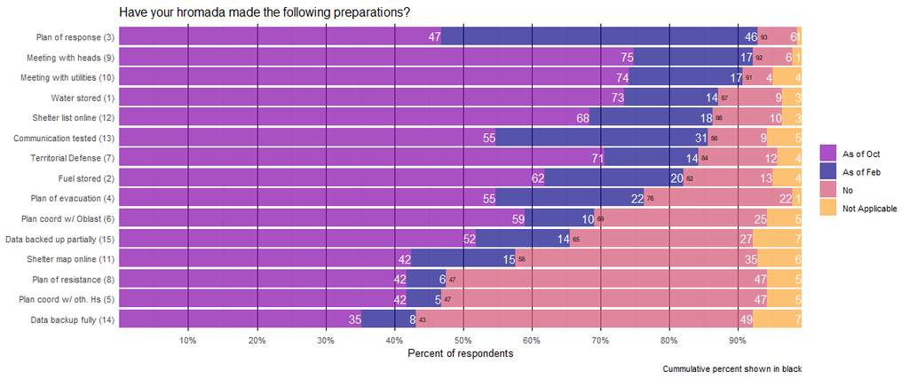

```r
d1 <-
  ds1_prep_ordinal_factors %>%
  pivot_longer(cols = preparation, names_to = "item_name") %>%
  group_by(item_name,value) %>%
  summarize(
    count = n_distinct(hromada_code)
    ,.groups = "drop"
  ) %>%
  group_by(item_name) %>%
  mutate(
    prop = count/sum(count, rm.na = T)
    ,pct = scales::percent(prop, accuracy = 1)
  ) %>%
  ungroup()

d2 <-
  ds1_prep_binary_factors %>%
  pivot_longer(cols = preparation, names_to = "item_name") %>%
  group_by(item_name,value) %>%
  summarize(
    count = n_distinct(hromada_code)
    ,.groups = "drop"
  ) %>%
  group_by(item_name) %>%
  mutate(
    prop = count/sum(count, rm.na = T)
    ,pct = scales::percent(prop, accuracy = 1)
  ) %>%
  ungroup()

d12 <-
  bind_rows(
    d1
    ,d2 %>% filter(value == "Yes")
  ) %>%
  left_join(
    d_meta_prep
  ) %>%
  arrange(item_name, value)

d_in <-
  d12 %>%
    mutate(
    display_name = label_en
    ,display_name = factor(
      display_name
      ,levels =  d12 %>%
        left_join(d_meta_prep) %>%
        filter(value == "Yes") %>%
        # filter(value == "Before Feb 24") %>%
        arrange(prop) %>%
        # arrange(desc(item_number)) %>%
        pull(label_en)
    ) # display_name
    ,value = fct_relevel(
      value
      , "As of Oct", "As of Feb","Yes", "No", "Not Applicable",
    ) %>% fct_rev()
  )

g <-
  d_in %>%
  {
  ggplot(
    data = (.) %>% filter(value !="Yes")
    ,aes(x=prop, y = display_name, fill=value)
  )+
  geom_col(position = position_stack()
           , alpha = .7
  )+
  geom_text(aes(label = str_remove(pct,"\\%"))
            ,hjust = 1
            , size = 4
            ,color="white"
            ,position = position_stack()
            ,data = . %>% filter(value !="Yes")
            )+
  geom_text(aes(label = str_remove(pct,"\\%"))
            ,hjust = -.5
            ,vjust = .5
            , size = 2
            ,color="black"
            ,position = position_stack()
            ,data = (.) %>% filter(value=="Yes") %>% mutate(value=NA)

            )+
  scale_x_continuous(
    breaks = seq(.1,1,.1)
    ,labels = scales::percent_format()
    ,expand = expansion(add=c(-.000,-.0))
  )+
  scale_fill_viridis_d(
    breaks = c("As of Oct", "As of Feb", "No", "Not Applicable"),
    begin = 0, end = .8, direction = 1, option = "plasma",guide= guide_legend(reverse=F)
    )+
  labs(
    title = "Have your hromada made the following preparations?"
    ,x = "Percent of respondents", y = NULL, fill = NULL
    ,caption = "Cummulative percent shown in black"
  )+
  theme(
    # panel.grid = element_blank()
    panel.grid.major.y  = element_blank()
    ,panel.border = element_blank()
    ,panel.grid.major.x = element_line(color = "black")
  )
  }

g
```

```r
# g %>% quick_save("2-preparation-summary-yes",w=12,h=5)
```

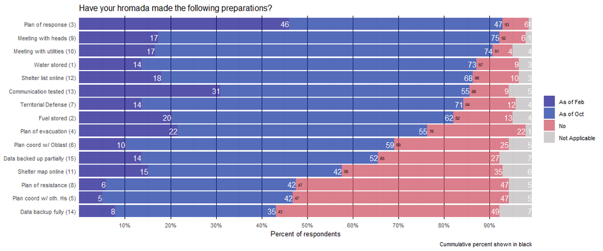

```r
d1 <-
  ds1_prep_ordinal_factors %>%
  pivot_longer(cols = preparation, names_to = "item_name") %>%
  group_by(item_name,value) %>%
  summarize(
    count = n_distinct(hromada_code)
    ,.groups = "drop"
  ) %>%
  group_by(item_name) %>%
  mutate(
    prop = count/sum(count, rm.na = T)
    ,pct = scales::percent(prop, accuracy = 1)
  ) %>%
  ungroup()

d2 <-
  ds1_prep_binary_factors %>%
  pivot_longer(cols = preparation, names_to = "item_name") %>%
  group_by(item_name,value) %>%
  summarize(
    count = n_distinct(hromada_code)
    ,.groups = "drop"
  ) %>%
  group_by(item_name) %>%
  mutate(
    prop = count/sum(count, rm.na = T)
    ,pct = scales::percent(prop, accuracy = 1)
  ) %>%
  ungroup()

d12 <-
  bind_rows(
    d1
    ,d2 %>% filter(value == "Yes")
  ) %>%
  left_join(
    d_meta_prep
  ) %>%
  arrange(item_name, value)

d_in <-
  d12 %>%
    mutate(
    display_name = label_en
    ,display_name = factor(
      display_name
      ,levels =  d12 %>%
        left_join(d_meta_prep) %>%
        filter(value == "Yes") %>%
        # filter(value == "Before Feb 24") %>%
        arrange(prop) %>%
        # arrange(desc(item_number)) %>%
        pull(label_en)
    ) # display_name
    ,value = fct_relevel(
      value
      , "As of Feb", "As of Oct", "Yes", "No", "Not Applicable",
    ) %>% fct_rev()
  )

g <-
  d_in %>%
  {
  ggplot(
    data = (.) %>% filter(value !="Yes")
    ,aes(x=prop, y = display_name, fill=value)
  )+
  geom_col(position = position_stack()
           , alpha = .7
  )+
  geom_text(aes(label = str_remove(pct,"\\%"))
            ,hjust = 1
            , size = 4
            ,color="white"
            ,position = position_stack()
            ,data = . %>% filter(value !="Yes")
            )+
  geom_text(aes(label = str_remove(pct,"\\%"))
            ,hjust = -.5
            ,vjust = .5
            , size = 2
            ,color="black"
            ,position = position_stack()
            ,data = (.) %>% filter(value=="Yes") %>% mutate(value=NA)

            )+
  scale_x_continuous(
    breaks = seq(.1,1,.1)
    ,labels = scales::percent_format()
    ,expand = expansion(add=c(-.000,-.0))
  )+
  scale_fill_manual(
    breaks = c("As of Feb", "As of Oct",  "No", "Not Applicable"),
    values = c("#0d0887", "#0b2c9c", "#cc475a", "#bab7b7")
    )+
  labs(
    title = "Have your hromada made the following preparations?"
    ,x = "Percent of respondents", y = NULL, fill = NULL
    ,caption = "Cummulative percent shown in black"
  )+
  theme(
    # panel.grid = element_blank()
    panel.grid.major.y  = element_blank()
    ,panel.border = element_blank()
    ,panel.grid.major.x = element_line(color = "black")
  )
  }

g
```

```r
# g %>% quick_save("2-preparation-summary-yes",w=12,h=5)
```

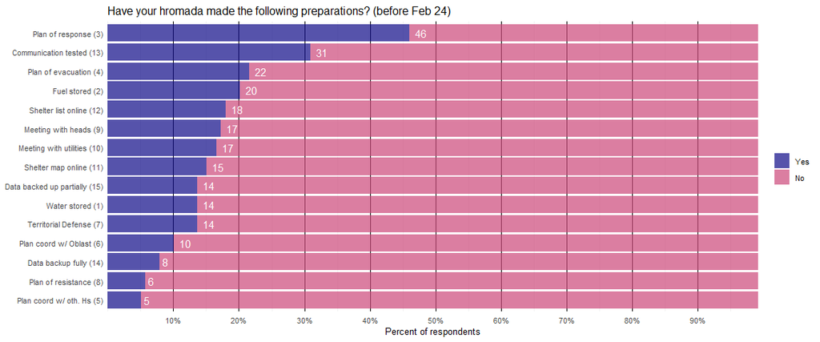

```r
d1 <-
  ds1_prep_binary_factors_feb %>%
  pivot_longer(cols = preparation, names_to = "item_name") %>%
  group_by(item_name,value) %>%
  summarize(
    count = n_distinct(hromada_code)
    ,.groups = "drop"
  ) %>%
  group_by(item_name) %>%
  mutate(
    prop = count/sum(count, rm.na = T)
    ,pct = scales::percent(prop, accuracy = 1)
  ) %>%
  ungroup()

d2 <-
  d1 %>%
  left_join(
    d_meta_prep
  ) %>%
  arrange(item_name, value)

d_in <-
  d2 %>%
    mutate(
    display_name = label_en
    ,display_name = factor(
      display_name
      ,levels =  d2 %>%
        left_join(d_meta_prep) %>%
        filter(value == "Yes") %>%
        # filter(value == "Before Feb 24") %>%
        arrange(prop) %>%
        # arrange(desc(item_number)) %>%
        pull(label_en)
    ) # display_name
    ,value = fct_relevel(
      value
      ,"Yes", "No"
    ) %>% fct_rev()
  )

g <-
  d_in %>%
  {
  ggplot(data = .,
    aes(x=prop, y = display_name, fill=value)
  )+
  geom_col(position = position_stack()
           , alpha = .7
  )+
  geom_text(aes(label = str_remove(pct,"\\%"))
            ,hjust = -.5
            , size = 4
            ,color="white"
            ,position = position_stack()
            ,data = . %>% filter(value == "Yes")
            )+
  scale_x_continuous(
    breaks = seq(.1,1,.1)
    ,labels = scales::percent_format()
    ,expand = expansion(add=c(-.000,-.0))
  )+
  scale_fill_viridis_d(
    breaks = c("Yes", "No"),
    begin = .5, end = .0, direction = 1, option = "plasma",guide= guide_legend(reverse=F)
    )+
  labs(
    title = "Have your hromada made the following preparations? (before Feb 24)"
    ,x = "Percent of respondents", y = NULL, fill = NULL
  )+
  theme(
    # panel.grid = element_blank()
    panel.grid.major.y  = element_blank()
    ,panel.border = element_blank()
    ,panel.grid.major.x = element_line(color = "black")
  )
  }

g
```

2.1 What questions were asked about preparations hromadas made?

```r
ds0 %>%
  select(preparation) %>%
  explore::describe_all() %>%
  left_join(
    meta_survey %>% filter(group=="preparation") %>% select(name,label_en,label)
    ,by=c("variable"="name")) %>%
  relocate(c("label_en","label"),.after = "variable") %>%
  select(1:3) %>%
  neat()
```

| variable | label_en | label |
| --- | --- | --- |
| prep_first_aid_water | Water stored (1) | Сформовані запаси товарів першої необхідності (вода, їжа, медичні засоби) |
| prep_first_aid_fuel | Fuel stored (2) | Сформовані запаси товарів першої необхідності (паливо) |
| prep_reaction_plan | Plan of response (3) | Оновлено чи затверджено план реагування на надзвичайні ситуації |
| prep_evacuation_plan | Plan of evacuation (4) | Складено спеціальний план евакуації населення при загрозі збройного конфлікту |
| prep_reaction_plan_oth_hromadas | Plan coord w/ oth. Hs (5) | Узгоджено план реагування/дій у разі повномасштабного вторгнення з представниками інших громад |
| prep_reaction_plan_oda | Plan coord w/ Oblast (6) | Узгоджено план реагування/дій у разі повномасштабного вторгнення з представниками ОДА |
| prep_dftg_creation | Territorial Defense (7) | Розпочато створення (добровольчого) формування територіальної громади |
| prep_national_resistance | Plan of resistance (8) | Затверджена та опрацьована представниками ОМС програма національного спротиву на території громади |
| prep_starosta_meeting | Meeting with heads (9) | Проведена зустріч зі старостами з приводу дій у випадку вторгнення |
| prep_communal_meetiing | Meeting with utilities (10) | Проведена зустріч з головами комунальних підприємств з приводу дій у випадку вторгнення |
| prep_online_map | Shelter map online (11) | Опублікована онлайн-мапа укриттів в громаді |
| prep_shelter_list | Shelter list online (12) | Опублікований перелік адрес укриттів в соцмережах або на сайті громади |
| prep_notification_check | Communication tested (13) | Перевірено засоби оповіщення населення |
| prep_backup | Data backup fully (14) | Здійснено повне централізоване резервне копіювання даних громади (критично важливої інформації, наприклад, даних про інфраструктуру) |
| prep_partly_backup | Data backed up partially (15) | Здійснено часткове резервне копіювання даних громади (критично важливої інформації, наприклад, даних про інфраструктуру) |

## Item-total correlations

> We can conceptualize hromadas’ the preparation for invasion as two quantities:  
> - `prep_score_feb` - the number of security measures implemented as of February 2022  
> - `prep_score_oct` - the number of security measures implemented as of October 2022

```r
ds1_prep %>% select(1:4) # + individual preparation items
```

```
# A tibble: 138 x 4
   hromada_code        prep_score_combo prep_score_feb prep_score_oct
   <chr>                          <dbl>          <dbl>          <dbl>
 1 UA05100110000070795               12              0             12
 2 UA05100170000071290                9              0              9
 3 UA05120070000075759               18              5             13
 4 UA05060130000030729               13              2             11
 5 UA05020110000052014               14              3             11
 6 UA07060370000022360               17              3             14
 7 UA07080170000013585               19              4             15
 8 UA07020130000036300               12              1             11
 9 UA07060290000054842               17              2             15
10 UA07060390000098670                7              0              7
# ... with 128 more rows
```

> We also compute `prep_score_combo`, which is a sum of `prep_score_feb` and `prep_score_oct`, the quantity equivalent to weighting the implementation of security measures prior to Feb 24, 2022 **twice as important**.

> These three scores are distributed as follows:

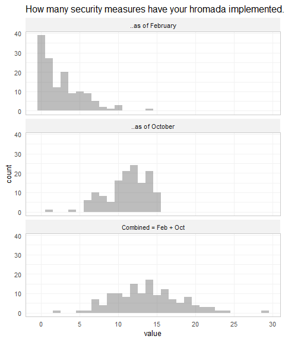

```r
g <-
  ds1_prep %>%
  select(starts_with("prep_score")) %>%
  pivot_longer(cols = everything(),names_to = "measure",values_to="value") %>%
  mutate(
    measure = factor(measure,
                        levels = c("prep_score_feb","prep_score_oct","prep_score_combo")
                        ,labels = c("..as of February","..as of October", "Combined = Feb + Oct")
                        )
  ) %>%
  ggplot(aes(x=value))+
  geom_histogram(binwidth = 1, alpha = .4)+
  scale_x_continuous(breaks = seq(0,30,5),minor_breaks = NULL)+
  facet_wrap("measure",ncol =1)+
  labs(
    title = "How many security measures have your hromada implemented..."
    # ,subtitle = "Combined score = February + October"
  )
g
```

```r
# g %>%  quick_save("score-distribution",w=3.5, h=6)
```

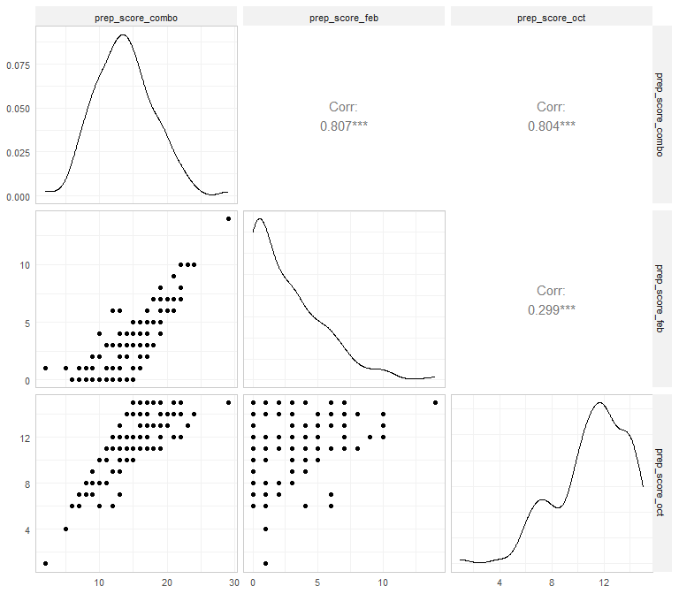

```r
ds1_prep %>% select(starts_with("prep_score")) %>% GGally::ggpairs()
```

```r
# Note that correlation coefficient is Pearson
```

> The item-total correlations indicates that all three preparedness scores are adequate unidimensional measures.

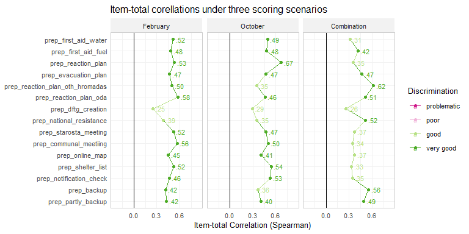

```r
# Step 1 - create data sets with re-coded item responses
# As of February 2022, how many of these security steps have been implemented?
d_feb <-
  ds_survey %>%
  mutate(
    across(
      .cols = preparation
      ,.fns = ~case_when(
        .  == 0 ~ 0 #"No"
        ,. == 1 ~ 0 #"After Feb 24"
        ,. == 2 ~ 1 #"Before Feb 24"
      )
    )
  ) %>%
  select(hromada_code, preparation)


# As of October 20200, how many of these security steps have been implemented?
d_oct <-
  ds_survey %>%
  mutate(
    across(
      .cols = preparation
      ,.fns = ~case_when(
        .  == 0 ~ 0 #"No"
        ,. == 1 ~ 1 #"After Feb 24"
        ,. == 2 ~ 1 #"Before Feb 24"
      )
    )
  ) %>%
  select(hromada_code, preparation)

# What is the combined score of preparedness if we give 2 points for having
# a security measure implemented as of February, and 1 point - as of October?
d_combo <-
  ds_survey %>%
  select(hromada_code, preparation)



# convert to matrices
m_feb <-
  ds1_prep %>% select(hromada_code, starts_with("prep_score_")) %>%
  left_join(d_feb) %>% # raw scores have been converted to binary for as of Feb
  select(-hromada_code) %>%
  make_corr_matrix(na_action = "remove", method="spearman")

m_oct <-
  ds1_prep %>% select(hromada_code, starts_with("prep_score_")) %>%
  left_join(d_oct) %>% # raw scores have been converted to binary for as of Oct
  select(-hromada_code) %>%
  make_corr_matrix(na_action = "remove", method="spearman")

m_combo <-
  ds1_prep %>% select(hromada_code, starts_with("prep_score_")) %>%
  left_join(d_combo) %>%
  select(-hromada_code) %>%
  make_corr_matrix(na_action = "remove", method="spearman")


d_item_total <-
  list(
    "Combination" = m_combo[,"prep_score_combo"]
    ,"February"  = m_feb[,"prep_score_feb"]
    ,"October"  = m_oct[,"prep_score_oct"]
  ) %>%
  as_tibble() %>%
  mutate(item_name = rownames(m_combo)) %>%
  filter(item_name != c("prep_score_combo","prep_score_feb","prep_score_oct")) %>%
  mutate(item_name = factor(item_name)) %>%
  relocate(item_name) %>%
  pivot_longer(
    cols = 2:4
    ,names_to = "scenario"
    ,values_to = "correlation"
  ) %>%
  mutate(
    discrimination = case_when(
      correlation <= 0  ~ "problematic"
      ,correlation > 0 & correlation < .2 ~ "poor"
      ,correlation >=.2 & correlation < .4 ~ "good"
      ,correlation >=.4  ~ "very good"
    ) %>% factor(levels = c("problematic","poor","good","very good"))
    ,scenario = scenario %>% factor(
      labels=c("February","October","Combination"))
    ,item_name = factor(item_name,levels = preparation) %>% fct_rev()
  )

discrimination_levels <- c(
  "problematic" = "#d01c8b"
  ,"poor"        = "#f1b6da"
  ,"good"        = "#b8e186"
  ,"very good"   = "#4dac26"
)

g_item_total <-
  d_item_total %>%
  ggplot(aes(x = item_name, y = correlation, color = discrimination, group = scenario))+
  geom_line(aes(group = "scenario"))+
  geom_point()+
  geom_text(aes(label=correlation %>% scales::number(accuracy = .01) %>% RemoveLeadingZero()),hjust=-.3
            ,size = 3)+
  geom_hline(aes( yintercept = 0))+
  facet_wrap("scenario",nrow=1)+
  scale_y_continuous(limits = c(-.3,.7), expand = expansion(add = c(0,.2)))+
  scale_color_manual(
    values = discrimination_levels
    , limits = names(discrimination_levels)
  )+
  coord_flip() +
  labs(
    title = "Item-total corellations under three scoring scenarios"
    ,y = "Item-total Correlation (Spearman)"
    ,x = NULL
    ,color = "Discrimination"
  )

g_item_total
```

```r
g_item_total %>% quick_save("item-total",w=8,h=4)
```

> While all three metrics should be considered during modeling, the next section demonstrates why and how the interpreations of these scores will differ

## Prep score change

> Let’s us visualize individual scores of invasion preparedness

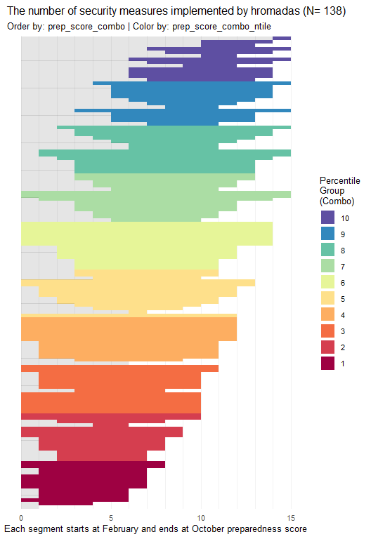

```r
d <-
  ds1_prep %>%
  select(hromada_code, starts_with("prep_score_")) %>%
arrange(prep_score_oct, prep_score_feb)

make_plot_prep_change_bw <- function(
    d
    ,order_by #= c("prep_score_feb","prep_score_oct")
    ,color_by #= "row_number_ntile"
    ,ntile_count = 10
){
  # browser()

  level_order <- d %>% arrange(!!!rlang::syms(order_by)) %>% pull(hromada_code)
  caption_text = paste0("Order by: ", paste0(order_by,collapse = " + "), " | Color by: ", color_by)
  g <-
    d %>%
    arrange(!!!rlang::syms(order_by)) %>%
    mutate(
      hromada_code = hromada_code %>% factor(levels = level_order)
      ,prep_score_combo_ntile = ntile(prep_score_combo,ntile_count)        %>% factor()
      ,prep_score_feb_ntile   = ntile(prep_score_feb,ntile_count) %>% factor()
      ,prep_score_oct_ntile   = ntile(prep_score_oct,ntile_count)  %>% factor()
      ,row_number_ntile       = ntile(row_number(),ntile_count)      %>% factor()
    ) %>%
    # graphing begins
    ggplot(aes(y=hromada_code, color = !!rlang::sym(color_by) ))+
    geom_segment(
      aes(
        y     = hromada_code
        ,yend = hromada_code
        ,x    = prep_score_feb
        ,xend = prep_score_oct
      )
      ,linewidth = 2 ,alpha = 1
    )+
    geom_segment(
      aes(
        y     = hromada_code
        ,yend = hromada_code
        ,x    = 0
        ,xend = prep_score_feb
      )
      ,linewidth = 2 ,alpha = .1
      , color = "black"
    )+
    scale_color_brewer(type="div", palette = "Spectral")+
    scale_x_continuous(
      breaks = seq(0,15,5),minor_breaks = seq(0,15,1)
      # ,limits = c(-10,25)
      )+
    labs(
      title = paste0("The number of security measures implemented by hromadas (N= ",
                     d %>% summarize(n=n_distinct(hromada_code)) %>% pull(n)
                     ,")")
      ,subtitle = caption_text
      ,x = "Each segment starts at February and ends at October preparedness score"
      # ,caption = caption_text
      ,y = NULL
      ,color = "Percentile\nGroup\n"
    )+
    theme(
      axis.text.y = element_blank()
      ,panel.grid.major.y = element_blank()
      ,panel.border = element_blank()
    )+
    guides(color = guide_legend(override.aes = list(linewidth=7), reverse=TRUE))
  return(g)
}
# Ordering by the total score (before + after OR sum(0|1|2))
g <- d %>% make_plot_prep_change_bw(order_by = "prep_score_combo",color_by = "prep_score_combo_ntile") #
g + labs(color = "Percentile\nGroup\n(Combo)")
```

```r
# g %>% quick_save("prep-change-segment-bw",w=5.5,h=9)
```

> However,this scoring method may not work for operationalizing preparedness as of October

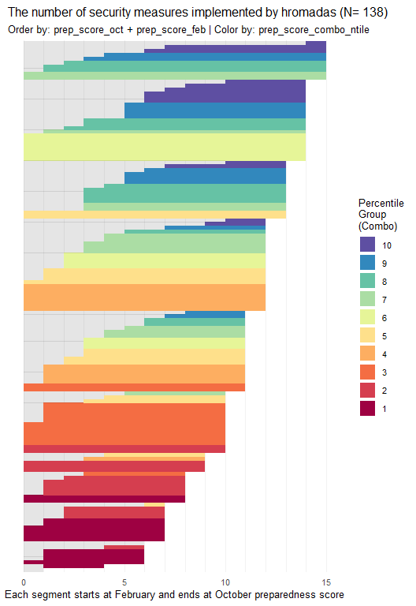

```r
g <- d %>% make_plot_prep_change_bw(order_by = c("prep_score_oct","prep_score_feb"), color_by = "prep_score_combo_ntile")
g + labs(color = "Percentile\nGroup\n(Combo)")
```

> or as of February

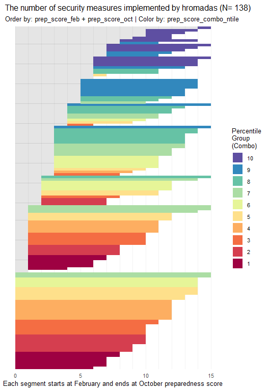

```r
g <- d %>% make_plot_prep_change_bw(order_by = c("prep_score_feb","prep_score_oct"), color_by = "prep_score_combo_ntile")
g + labs(color = "Percentile\nGroup\n(Combo)")
```

**Conclusion**

> Both `prep_score_feb` and `prep_score_oct` are meaningful, adequate unidimensional measures with a straightforward interpretation: *Number of security measures implemented as of a given date*.

> The measure `prep_score_combo` is also an adequate unidimensional measure, but it does not have a clear interpretation of its value.

# 3. Information

```r
meta_survey %>% filter(group=="information_hat") %>% pull(label) %>% cat()
```

```
Який з перелічених нижче засобів використовується громадою для інформування населення...
```

> The most popular channel of communication for hromadas before February 24th and still is Facebook. Before February 24th, only about a quarter of hromadas in our sample had accounts on Viber and Telegram.  
> After February, hromadas doubled their use of alternative channels for communicating with their hromada: Viber, Telegram, Chat for getting help, hotline - now about half of hromadas have official groups on Viber and a hotline.

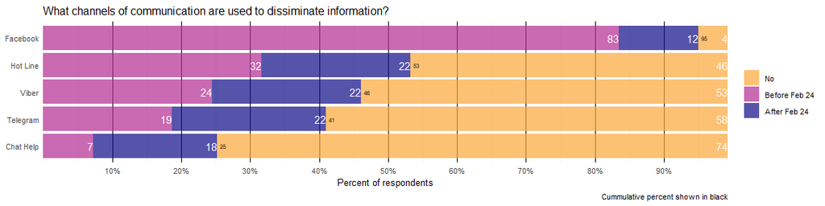

> Most hromadas had at least one account in social networks before the invasion.

[figure not shown]

```r
d <-
  ds0 %>%
  select(hromada_code,head_hromada_communication, facebook,viber,telegram ) %>%
  pivot_longer(cols = c("facebook","viber","telegram")) %>%
  mutate(
    had_sn_before = case_when(
      value %in% c(0,1) ~ "No cccount before Feb24"
      ,value %in% c(2)  ~ "Had cccount before Feb24"
    )
  ) %>%
  arrange(hromada_code, head_hromada_communication) %>%
  group_by(hromada_code,head_hromada_communication) %>%
  mutate(
    had_any_sn_before_feb24 = sum(value==2,na.rm = T)>0
  ) %>%
  ungroup() %>%
  distinct(hromada_code, head_hromada_communication,had_any_sn_before_feb24) %>%
  mutate(
    time_per_week = fct_recode(head_hromada_communication,
        "1"  = "once_a_week"
      , "7"  = "once_a_day"
      , "0"  = "none"
      , "3"  = "few_times_a_week"
      , "15" = "2_3_times"
    ) %>% as.character() %>% as.integer()
    , head_hromada_communication = fct_recode(
      head_hromada_communication,
       "Once a week"      = "once_a_week"
      ,"Once a day"       = "once_a_day"
      ,"Never"            = "none"
      ,"Few times a week" = "few_times_a_week"
      ,"2-3 times a day"  = "2_3_times"
    ) %>% factor( levels = c(
       "Never"
       ,"Once a week"
       ,"Few times a week"
       ,"Once a day"
       ,"2-3 times a day"
    )
    )
  )
(d %>% make_bi_freq_graph("had_any_sn_before_feb24")) +
  labs(
    title = "Did hromadas have account on any social network before the invasion?"
    ,subtitle = "Social networks considered: Facebook, Viber, Telegram"
    ,y = NULL, x = NULL, fill = "Had account"
  ) +
  scale_x_discrete(labels=c('TRUE' = 'Had account', 'FALSE' = 'No account')) +
  scale_fill_discrete(labels=c('TRUE' = 'Had account', 'FALSE' = 'No account'))
```

```r
meta_survey %>% filter(group=="information_freq") %>% pull(label) %>% cat()
```

```
Як часто в середньому голова громади звертався (відео чи повідомлення) до населення громади стосовно стану справ у перший місяць від повномасштабного вторгнення?
```

> Almost all hromada heads actively communicated with their hromada during the first month of the invasion: 95% addressed the hromada once a week or more, and 37% did it daily.

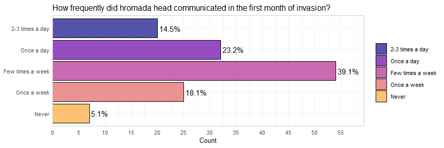

```r
(ds0 %>%
  mutate(

    head_hromada_communication = fct_recode(
      head_hromada_communication,
       "Once a week"      = "once_a_week"
      ,"Once a day"       = "once_a_day"
      ,"Never"            = "none"
      ,"Few times a week" = "few_times_a_week"
      ,"2-3 times a day"  = "2_3_times"
    ) %>% factor( levels = c(
       "Never"
       ,"Once a week"
       ,"Few times a week"
       ,"Once a day"
       ,"2-3 times a day"
    )
    )
  ) %>%
  make_bi_freq_graph("head_hromada_communication") )+
  labs(
    title = "How frequently did hromada head communicated in the first month of invasion?"
    ,x = NULL, fill = NULL
  )
```

> Mayors of hromadas that had any social account before February 24th on average adressed hromada about the state of affairs significantly more during first month of invasion than those that didn’t have.

[figure not shown]

```r
d %>%
  group_by(had_any_sn_before_feb24) %>%
  summarize(mean_times_per_week = mean(time_per_week,na.rm =T)) %>%
  ggplot(aes(x=mean_times_per_week, y= had_any_sn_before_feb24,
             fill = had_any_sn_before_feb24))+
  geom_col()+
  geom_text(aes(label=scales::comma(mean_times_per_week)))+
  labs(
    title = "How frequently did heads of hromadas communicate with the community during the first month of invation \ndepending on having any social account before 24th February?"
    ,subtitle = "Social networks considered: Facebook, Viber, Telegram"
    ,y = NULL, x = "Average times per week", fill = "Had account on\nany social network"
  ) +
  scale_y_discrete(labels=c('TRUE' = 'Had account', 'FALSE' = 'No account')) +
  scale_fill_discrete(labels=c('TRUE' = 'Had account', 'FALSE' = 'No account'))
```

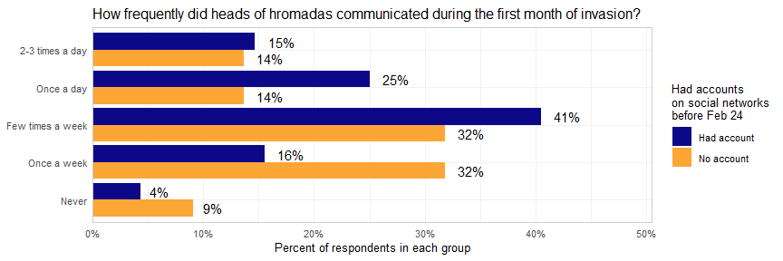

```r
d %>%
  group_by(head_hromada_communication,had_any_sn_before_feb24) %>%
  summarize(
    hromada_count = n_distinct(hromada_code)
    ,.groups = "drop"
  ) %>%
  group_by(had_any_sn_before_feb24) %>%
  mutate(
    prop = hromada_count/sum(hromada_count)
    ,pct = scales::percent(prop, accuracy = 1)
  ) %>%
  ggplot(aes(x=prop, y = head_hromada_communication, fill = had_any_sn_before_feb24))+
  geom_col(position = position_dodge())+
  geom_text(aes(label = pct), hjust = -.5,position = position_dodge(width = .9))+
  scale_x_continuous(labels = scales::percent_format(),expand = expansion(add = c(0,.1)))+
  ggplot2::scale_fill_viridis_d(begin = 0, end = .8, direction = -1, option = "plasma",guide= guide_legend(reverse=T)
                                ,labels = c('TRUE' = 'Had account', 'FALSE' = 'No account')
    )+
  labs(
    title = "How frequently did heads of hromadas communicated during the first month of invasion?"
    ,fill = "Had accounts\non social networks\nbefore Feb 24"
    ,x = "Percent of respondents in each group"
    , y = NULL
  )
```

# 4. National Resistance

```r
meta_survey %>% filter(name=="dftg_creation") %>% pull(label) %>% cat()
```

```
Чи було у вашій громаді офіційно сформоване добровольче формування територіальної громади?
```

> About a third of hromadas in our survey had not yet created a volunteer defense force of territorial communities (VDF) as of October.

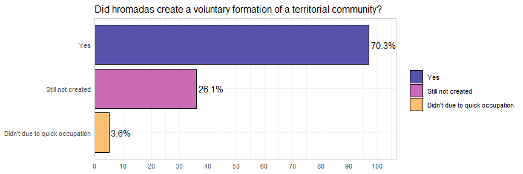

```r
d <- ds0 %>%
  select(hromada_code, dftg_creation, type, region_en) %>%
  mutate(dftg_creation = factor(dftg_creation, levels = c('not_able', 'still_not', 'yes')),
         dftg_creation = fct_recode(dftg_creation,
             'Yes' = 'yes'
            ,"Didn't due to quick occupation" = 'not_able'
            ,'Still not created' = 'still_not')
  )

(d %>% make_bi_freq_graph('dftg_creation')) +
  labs(
    title = "Did hromadas create a voluntary formation of a territorial community?"
    ,y = NULL, x = NULL, fill = NULL
  )
```

> Among village and urban village communities, a higher proportion of hromadas had not yet created a volunteer defense force of territorial communities (VDF).

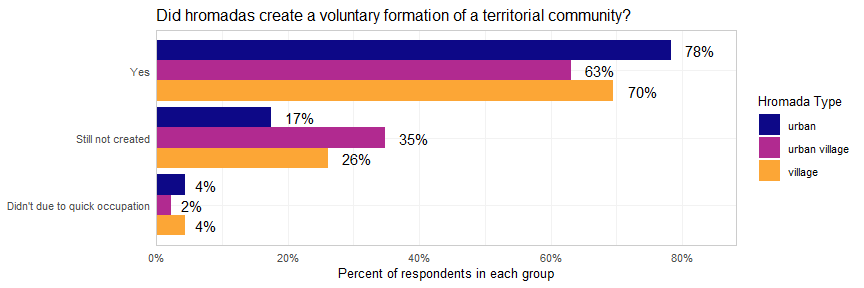

```r
d %>%
  group_by(type) %>%
  count(dftg_creation) %>%
  mutate(prop = n/sum(n)
         ,pct = scales::percent(prop, accuracy = 1)) %>%
  ggplot(aes(x=prop, y = dftg_creation, fill = type))+
  geom_col(position = position_dodge())+
  geom_text(aes(label = pct), hjust = -.5,position = position_dodge(width = .9))+
  scale_x_continuous(labels = scales::percent_format(),expand = expansion(add = c(0,.1)))+
  ggplot2::scale_fill_viridis_d(begin = 0, end = .8, direction = -1, option = "plasma",guide= guide_legend(reverse=T)
  )+
  labs(
    title = "Did hromadas create a voluntary formation of a territorial community?"
    ,fill = "Hromada Type"
    ,x = "Percent of respondents in each group"
    , y = NULL
  )
```

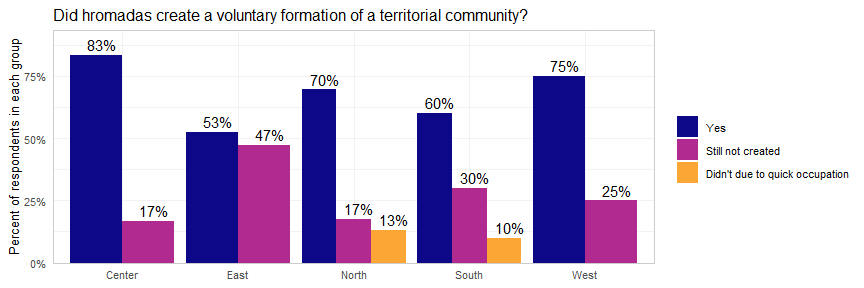

```r
d %>%
  group_by(region_en) %>%
  count(dftg_creation) %>%
  mutate(prop = n/sum(n)
         ,pct = scales::percent(prop, accuracy = 1)) %>%
  ggplot(aes(x=prop, y = region_en, fill = fct_rev(dftg_creation)))+
  geom_col(position = position_dodge())+
  geom_text(aes(label = pct), hjust = .3, vjust = -.4, position = position_dodge(width = .9))+
  scale_x_continuous(labels = scales::percent_format(),expand = expansion(add = c(0,.1)))+
  scale_fill_viridis_d(
    begin = 0, end = .8, direction = 1, option = "plasma",guide= guide_legend(reverse=F)
    )+
  labs(
    title = "Did hromadas create a voluntary formation of a territorial community?"
    ,fill = NULL
    ,x = "Percent of respondents in each group"
    , y = NULL
  )+
  coord_flip()
```

> Here you can see the timeline of creation of these forces for our sample.

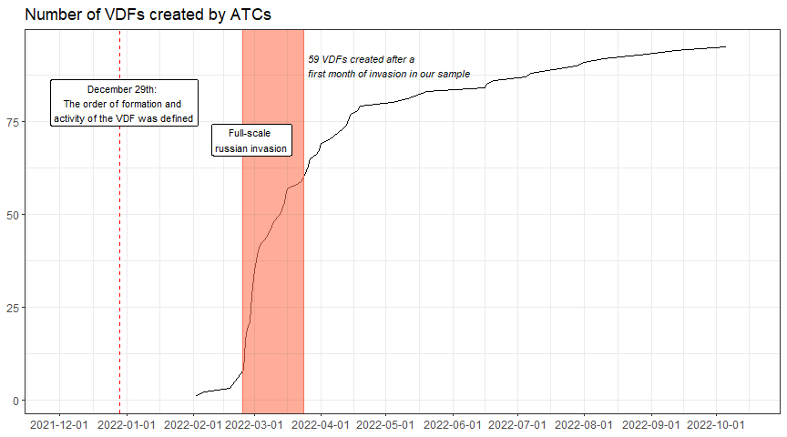

```r
d <- ds0 %>% select(dftg_creation_date) %>% group_by(dftg_creation_date) %>%
  summarise(n = n()) %>%
  filter(!is.na(dftg_creation_date) & dftg_creation_date > '2021-12-28') %>%
  mutate(cum = cumsum(n))

p <- d %>%
  ggplot(aes(x = dftg_creation_date, y = cum)) +
  geom_line() +
  geom_vline(aes(xintercept = as.POSIXct('2022-02-24')),
             color = 'red', linetype = 'dashed') +
  geom_vline(aes(xintercept = as.POSIXct('2021-12-29')),
             color = 'red', linetype = 'dashed') +
  geom_rect(aes(xmin = as.POSIXct('2022-02-24'), xmax = as.POSIXct('2022-03-24'),
                ymin = -Inf, ymax = Inf),
            color = 'coral1', fill = 'coral1', alpha = 0.02) +
  theme_bw() +
  theme(axis.title.y = element_blank(),
        axis.title.x = element_blank()) +
  scale_x_datetime(limits = c(as.POSIXct('2021-12-01'), as.POSIXct('2022-10-15')), date_breaks = '1 month') +
  annotate(geom = 'label', x = as.POSIXct('2021-12-31'), y = 80, size = 3,
           label = 'December 29th: \nThe order of formation and \nactivity of the VDF was defined') +
  annotate(geom = 'label', x = as.POSIXct('2022-02-28'), y = 70, size = 3,
           label = 'Full-scale \nrussian invasion') +
  annotate(geom = 'text', x = as.POSIXct('2022-03-26'), y = 90, hjust = 0, size = 3,
           label = '59 VDFs created after a \nfirst month of invasion in our sample', fontface = 'italic') +
  labs(title = 'Number of VDFs created by ATCs')
p
```

```r
d <- ds0 %>% select(dftg_creation_date, type) %>% group_by(dftg_creation_date, type) %>%
  filter(!is.na(dftg_creation_date) & dftg_creation_date > '2021-12-28') %>%
  summarise(n = n()) %>%
  pivot_wider(values_from = n, names_from = type) %>%
  rename(c = 'міська', v = 'сільська', s = 'селищна') %>%
  ungroup() %>%
  mutate(c = replace_na(c, 0),
         v = replace_na(v, 0),
         s = replace_na(s, 0),
         c_cum = cumsum(c),
         s_cum = cumsum(s),
         v_cum = cumsum(v)) %>%
  select(-c(c,v,s)) %>%
  pivot_longer(-dftg_creation_date, values_to = 'n', names_to = 'type')

p <- d %>%
  ggplot(aes(x = dftg_creation_date, y = n, color = type)) +
  geom_point() +
  geom_vline(aes(xintercept = as.POSIXct('2022-02-24')),
             color = 'red', linetype = 'dashed') +
  geom_vline(aes(xintercept = as.POSIXct('2021-12-29')),
             color = 'red', linetype = 'dashed') +
  geom_rect(aes(xmin = as.POSIXct('2022-02-24'), xmax = as.POSIXct('2022-03-24'),
                ymin = -Inf, ymax = Inf),
            color = 'coral1', fill = 'coral1', alpha = 0.007) +
  theme_bw() +
  theme(axis.title.y = element_blank(),
        axis.title.x = element_blank(),
        legend.position = 'top') +
  scale_x_datetime(limits = c(as.POSIXct('2021-12-01'), as.POSIXct('2022-10-15')), date_breaks = '1 month') +
  scale_y_continuous(limits = c(0,40)) +
  scale_color_discrete(labels = c('c_cum' = 'City', 's_cum' = 'Urban Village', 'v_cum' = 'Village')) +
  annotate(geom = 'label', x = as.POSIXct('2021-12-31'), y = 36, size = 3,
           label = 'December 29th: \nThe order of formation and \nactivity of the voluntary \nformations of ATC was defined') +
  annotate(geom = 'label', x = as.POSIXct('2022-02-28'), y = 37, size = 3,
           label = 'Full-scale \nrussian invasion') +
  annotate(geom = 'text', x = as.POSIXct('2022-03-26'), y = 37, hjust = 0, size = 3,
           label = '59 voluntary formations of ATC \nafter a first month', fontface = 'italic') +
  labs(title = 'Number of DFTG created by ATCs', color = NULL)
p
```

[output not shown]

> Only a few hromadas have created VDF before the invasion.  
> However, more than a half quickly reacted and managed to create VDF in the first month of the invasion.  
> Moreover, there are differences in speed of reaction by hromada type.

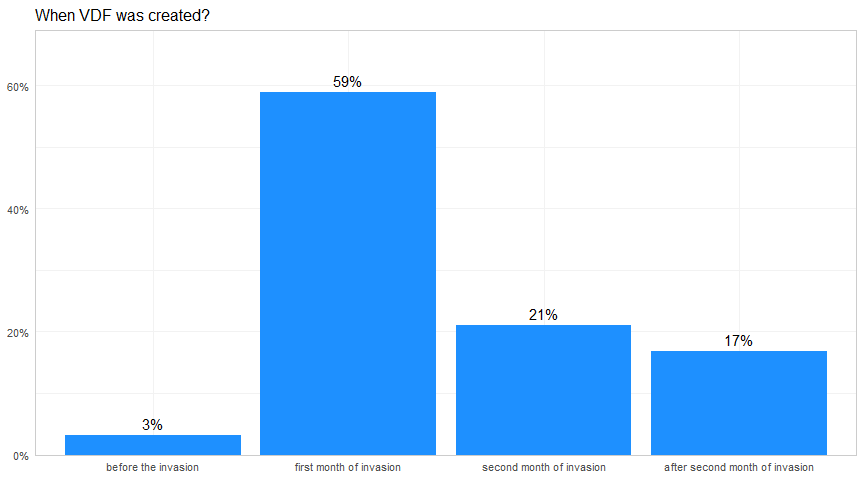

```r
before <- interval(start = "2021-12-28", end = "2022-02-23")
first_month <- interval(start = "2022-02-24", end = "2022-03-23")
second_month <- interval(start = "2022-03-24", end = "2022-04-23")
third_and_more <- interval(start = "2022-04-24", end = "2022-11-30")


d <- ds0 %>% filter(!is.na(dftg_creation_date) & dftg_creation_date > '2021-12-28') %>%
  mutate(
    invasion_duration = case_when(dftg_creation_date %within% before ~ "before the invasion",
                                  dftg_creation_date %within% first_month ~ "first month of invasion",
                                  dftg_creation_date %within% second_month ~ "second month of invasion",
                                  dftg_creation_date %within% third_and_more ~ "after second month of invasion"),
    invasion_duration = factor(invasion_duration, levels = c("before the invasion", "first month of invasion",
                                                             "second month of invasion", "after second month of invasion")))

p <- d %>%
  select(invasion_duration) %>%
  count(invasion_duration) %>%
  mutate(prop = n/sum(n)
         ,pct = scales::percent(prop, accuracy = 1)) %>%
  ggplot(aes(y=prop, x = invasion_duration))+
  geom_col(position = position_dodge(), fill = "dodgerblue")+
  geom_text(aes(label = pct), position = position_dodge(width = 1), vjust = -0.5)+
  scale_y_continuous(labels = scales::percent_format(),expand = expansion(add = c(0,.1)))+
  labs(
    title = "When VDF was created?"
    ,x = NULL
    ,y = NULL
  )
p
```

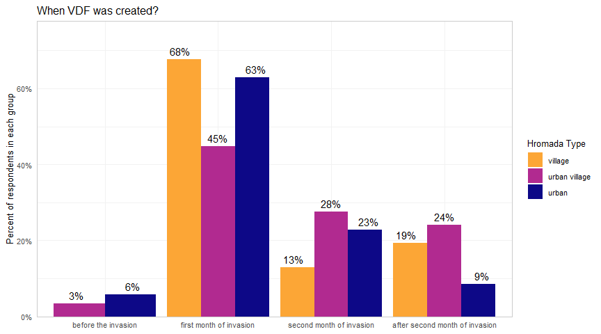

```r
p <- d %>%
  select(invasion_duration, type) %>%
  group_by(type) %>%
  count(invasion_duration) %>%
  mutate(prop = n/sum(n)
         ,pct = scales::percent(prop, accuracy = 1)) %>%
  ggplot(aes(y=prop, x = invasion_duration, fill = type))+
  geom_col(position = position_dodge())+
  geom_text(aes(label = pct), position = position_dodge(width = 1), vjust = -0.5)+
  scale_y_continuous(labels = scales::percent_format(),expand = expansion(add = c(0,.1)))+
  ggplot2::scale_fill_viridis_d(begin = 0, end = .8, direction = -1, option = "plasma")+
  labs(
    title = "When VDF was created?"
    ,fill = "Hromada Type"
    ,y = "Percent of respondents in each group"
    , x = NULL
  )

p
```

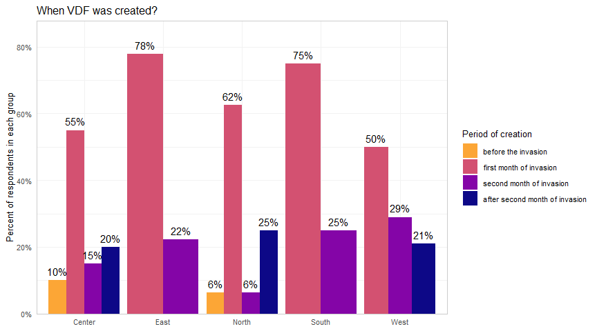

```r
p <- d %>%
  select(invasion_duration, region_en) %>%
  group_by(region_en) %>%
  count(invasion_duration) %>%
  mutate(prop = n/sum(n)
         ,pct = scales::percent(prop, accuracy = 1)) %>%
  ggplot(aes(y=prop, x = region_en, fill = invasion_duration))+
  geom_col(position = position_dodge())+
  geom_text(aes(label = pct), position = position_dodge(width = .9), vjust = -.6)+
  scale_y_continuous(labels = scales::percent_format(),expand = expansion(add = c(0,.1)))+
  ggplot2::scale_fill_viridis_d(begin = 0, end = .8, direction = -1, option = "plasma")+
  labs(
    title = "When VDF was created?"
    ,fill = "Period of creation"
    ,y = "Percent of respondents in each group"
    , x = NULL
  )

p
```

> Almost all communities provided at least products for military, significant majority allocated rooms and provided money and transport.

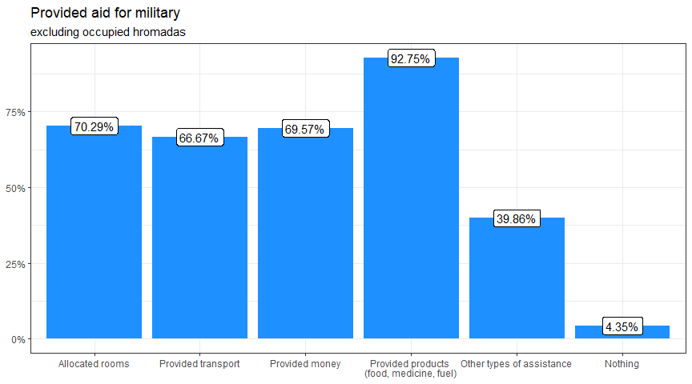

```r
help_military_levels <- c('rooms', 'transport', 'money', 'products', 'other', "none")

d <- ds0 %>% select(hromada_code, starts_with('help_for_military/')) %>%
  pivot_longer(-hromada_code, names_to = 'help', values_to = 'count') %>%
  count(help, count) %>% group_by(help) %>%
  mutate(freq = n/sum(n),
         help = str_remove(help, 'help_for_military/')) %>%
  filter(count == 1)

p <- d %>%
  ggplot(aes(x = factor(help, levels = help_military_levels), y = freq)) +
  geom_col(fill = "dodgerblue") +
  geom_label(aes(label = scales::percent(freq)))  +
  theme_bw() +
  theme(axis.title.y = element_blank(),
        axis.title.x = element_blank()) +
  labs(title = 'Provided aid for military', subtitle = "excluding occupied hromadas") +
  scale_y_continuous(labels = scales::percent) +
  scale_x_discrete(labels=c('rooms' = 'Allocated rooms', 'transport' = 'Provided transport',
                            "money" = "Provided money", "products" = "Provided products \n(food, medicine, fuel)",
                            "other" = "Other types of assistance", "none" = "Nothing"))

p
```

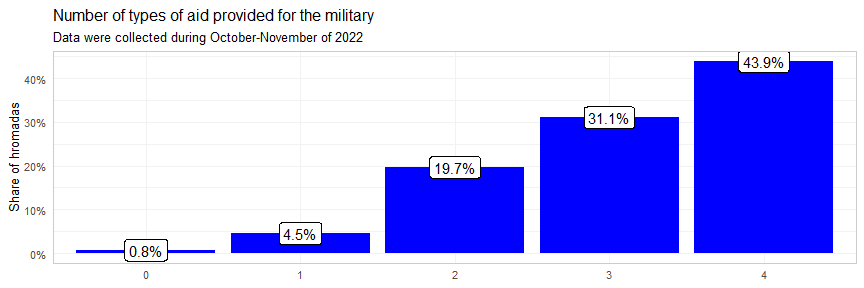

```r
ds0 %>%
  count(help_military_count) %>%
  filter(!is.na(help_military_count)) %>%
  mutate(freq = n/sum(n)) %>%
  ggplot(aes(x = factor(help_military_count), y = freq)) +
  geom_bar(stat = "identity", fill = "blue") +
  geom_label(aes(label = scales::percent(freq)))  +
  scale_y_continuous(labels = scales::percent) +
  labs(
    title = "Number of types of aid provided for the military"
    ,subtitle = "Data were collected during October-November of 2022"
    ,y = "Share of hromadas", x = NULL, fill = NULL
  )
```

```r
d <- ds0 %>% filter(`help_for_military/transport` == 1) %>%
  select(hromada_code, transport_help_communal_coded, transport_help_bought_coded) %>%
  pivot_longer(-hromada_code, names_to = 'transport_type', values_to = 'number_transport') %>%
  mutate(transport_type = case_when(
  transport_type == 'transport_help_bought_coded' ~ 'Bought by community',
  transport_type == 'transport_help_communal_coded' ~ 'From communal enterprises'),
  number_transport = case_when(number_transport == 0 ~ NA_real_,
                               TRUE ~ number_transport)
  )

beeswarm(d$number_transport ~ d$transport_type,  method='swarm',
         main = 'Number of vehicles provided for military', xlab = NA, ylab = NA,
         col=c(1, 2), pch = 19, cex = 0.7,
         horizontal = TRUE, corral = 'random', xaxt="n")
axis(1, at=seq(0, 200, by = 10), las=2)
bxplot(d$number_transport ~ d$transport_type, horizontal = TRUE, add = TRUE, lwd = 1.2)
```

[output not shown]

# 5. Administrative Adaptation

```r
meta_survey %>% filter(name=="percent_working_march") %>% pull(label) %>% cat()
```

```
Який відсоток працівників виконавчих органів влади (від усіх працівників станом на 23 лютого) фактично працювали станом на 1 березня (в тому числі віддалено)?
```

```r
meta_survey %>% filter(name=="percent_working_now") %>% pull(label) %>% cat()
```

```
Який відсоток працівників виконавчих органів влади (від усіх працівників станом на 23 лютого) фактично працюють станом на сьогоднішній день (в тому числі віддалено)?
```

> Questions regarding the percentage of working administrative staff were not effective: Most hromadas reported that 90-100% of staff were working both in March and October, and there was no difference between these numbers that would indicate administrative adaptation.

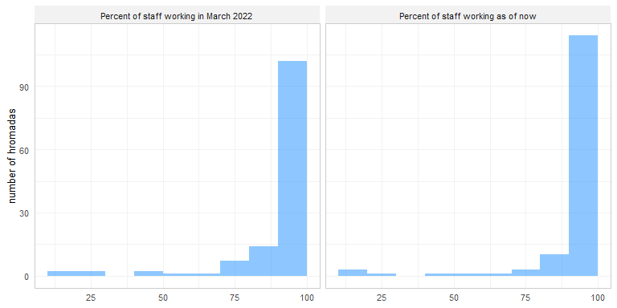

```r
g <-  ds0 %>%
  select(starts_with("percent_working")) %>%
  pivot_longer(cols = everything(),names_to = "measure",values_to="value") %>%
  mutate(
    measure = factor(measure,
                        levels = c("percent_working_march","percent_working_now")
                        ,labels = c("Percent of staff working in March 2022",
                                    "Percent of staff working as of now")
                        )
  ) %>%
  ggplot(aes(x=value))+
  geom_histogram(binwidth = 100, alpha = .5, breaks=c(10,20,30,40,50,60,70,80,90,100), fill = "dodgerblue")+
  facet_wrap("measure",ncol =5) +
  labs(
    y='number of hromadas'
    ,x=NULL
  )
g
```

```r
g %>%  quick_save("score-distribution",w=4, h=6)
```

> 73% of communities regularly coordinate actions, typically several times a week or more.  
> Communities affected by war differ from those in peaceful regions; they were more likely to both have daily meetings with other communities and also have no meetings at all.

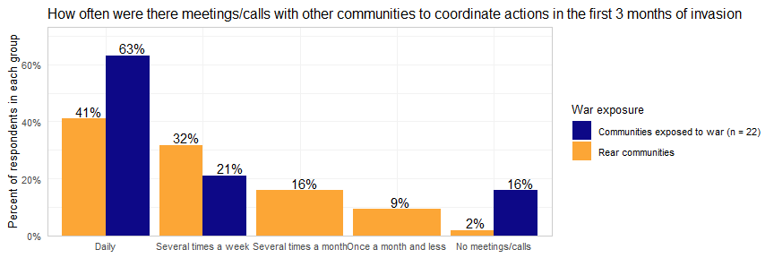

```r
d <- ds0 %>%
   filter(!is.na(commun_between_hromadas)) %>%
  mutate(
    freq_hromadas_com = fct_recode(
      commun_between_hromadas,
       "Daily"      = "Daily"
      ,"Several times a week"       = "Several times a week"
      ,"Several times a month" = "Several times a month"
      ,"Once a month and less" = "Once a month and less"
      ,"No meetings/calls" = "No meetings/calls"
    ) %>% factor( levels = c(
       "Daily"
       ,"Several times a week"
       ,"Several times a month"
       ,"Once a month and less"
       ,"No meetings/calls"
    )
    )
  ) %>%
  select(freq_hromadas_com, occupation_and_combat_fct, hromada_code)

d %>%
  group_by(freq_hromadas_com,occupation_and_combat_fct) %>%
  summarize(
    hromada_count = n_distinct(hromada_code)
    ,.groups = "drop"
  ) %>%
  group_by(occupation_and_combat_fct) %>%
  mutate(
    prop = hromada_count/sum(hromada_count)
    ,pct = scales::percent(prop, accuracy = 1)
  ) %>%
  ggplot(aes(y=prop, x = freq_hromadas_com, fill = occupation_and_combat_fct))+
  geom_col(position = position_dodge())+
  geom_text(aes(label = pct), hjust = .3, vjust = -.2, position = position_dodge(width = .9))+
  scale_y_continuous(labels = scales::percent_format(),expand = expansion(add = c(0,.1)))+
  ggplot2::scale_fill_viridis_d(begin = 0, end = .8, direction = -1, option = "plasma",guide= guide_legend(reverse=T)
                                ,labels = c('TRUE' = 'Had account', 'FALSE' = 'No account')
    )+
  labs(
    title = "How often were there meetings/calls with other communities to coordinate actions in the first 3 months of invasion"
    ,fill = "War exposure"
    ,y = "Percent of respondents in each group"
    ,x = NULL
  )
```

# 6. Evacuation

> In most rear communities, evacuation of citizens was not necessary. However, of the communities affected by war, 63% required evacuation and 36% were successful in doing so.

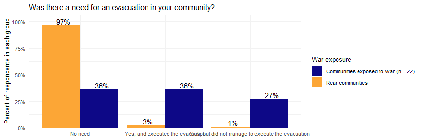

```r
d <- ds0 %>%
  mutate(
    evacuation_fct = fct_recode(
      evacuation,
       "No need"      = "no"
      ,"Yes, and executed the evacuation"       = "yes_executed"
      ,"Yes, but did not manage to execute the evacuation" = "yes_notexecuted"
    ) %>% factor( levels = c(
       "No need"
       ,"Yes, and executed the evacuation"
       ,"Yes, but did not manage to execute the evacuation"
    )))

d %>%
  group_by(evacuation_fct,occupation_and_combat_fct) %>%
  summarize(
    hromada_count = n_distinct(hromada_code)
    ,.groups = "drop"
  ) %>%
  group_by(occupation_and_combat_fct) %>%
  mutate(
    prop = hromada_count/sum(hromada_count)
    ,pct = scales::percent(prop, accuracy = 1)
  ) %>%
  ggplot(aes(y=prop, x = evacuation_fct, fill = occupation_and_combat_fct))+
  geom_col(position = position_dodge())+
  geom_text(aes(label = pct), hjust = .3, vjust = -.2, position = position_dodge(width = .9))+
  scale_y_continuous(labels = scales::percent_format(),expand = expansion(add = c(0,.1)))+
  ggplot2::scale_fill_viridis_d(begin = 0, end = .8, direction = -1, option = "plasma",guide= guide_legend(reverse=T))+
  labs(
    title = "Was there a need for an evacuation in your community?"
    ,fill = "War exposure"
    ,y = "Percent of respondents in each group"
    ,x = NULL
  )
```